# Main Figures

Sean Maden

10/8/2020

# Figure 1

Some details about the platforms of interest are as follows:

| platform_id | platform_name | release_year | release_month |
| --- | --- | --- | --- |
| GPL13534 | HM450K | 2011 | May 2011 |
| GPL21145 | EPIC | 2015 | Nov. 2015 |
| GPL8490 | HM27K | 2009 | Apr. 2009 |

## 1A Available GEO samples (GSM IDs) by year, platform, and type

Obtain sample (GSM IDs) and study (GSE IDs) summaries from queries to GEO with queries to Entrez utilities. With [Entrez utilities](https://www.ncbi.nlm.nih.gov/books/NBK179288/) installed, navigate to the directory with the script “eqplot.py” and run:

```
python3 eqplot.py
```

This will cause data queries to the GEO servers, and result in the creation of several new files, “gsmyeardata”, “gsmidatyrdata”, “gseyeardata”, and “gseidatyrdata”. Finally, run the script “fig1a.R” to make the plot.

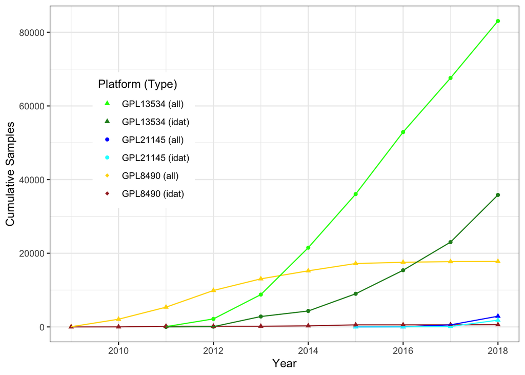

```r
script.name <- "fig1a.R"
source(file.path(scripts.dir, script.name))
fig1a
```

## 1B

See data analyses vignette in [`recountmethylation`](https://bioconductor.org/packages/devel/bioc/vignettes/recountmethylation/inst/doc/recountmethylation_data_analyses.pdf)

# Figure 2

## 2A BeadArray control outcomes

Source the script “fig2a.R”. This creates control outcomes from BeadArray signals in Table S2, then generates the plot object.

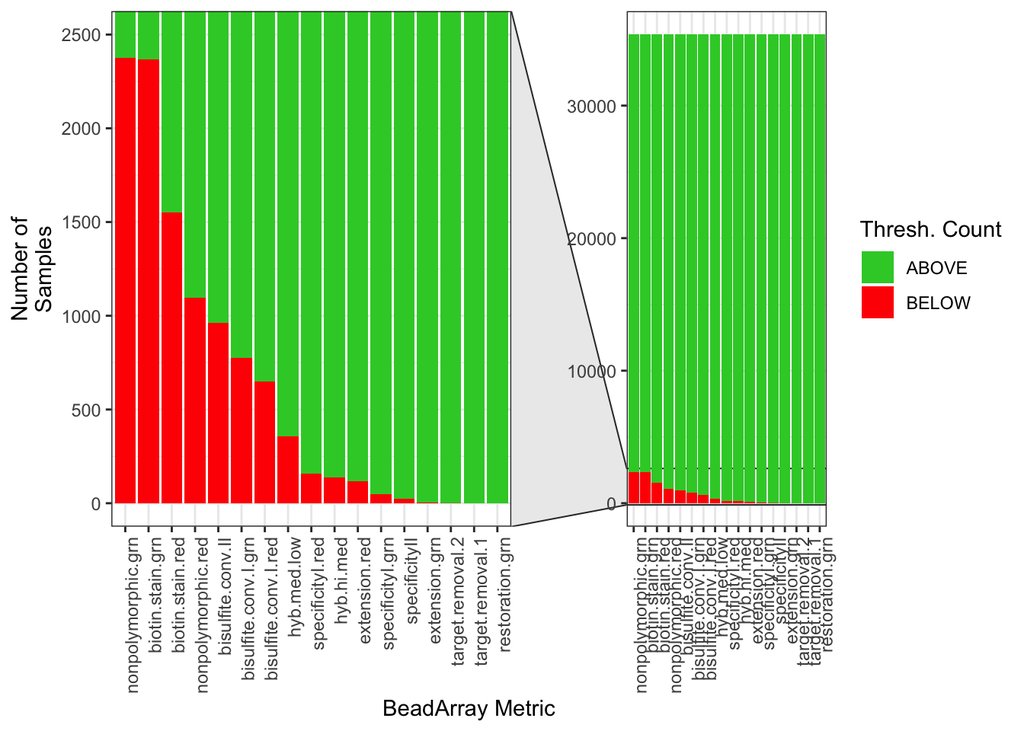

```r
script.name <- "fig2a.R"
source(file.path(scripts.dir, script.name))
fig2a
```

## 2B Quality signals, by storage condition

See data analyses vignette in [`recountmethylation`](https://bioconductor.org/packages/devel/bioc/vignettes/recountmethylation/inst/doc/recountmethylation_data_analyses.pdf)

## 2D Study-level quality assessments

```r
script.name <- "fig2d.R"
source(file.path(scripts.dir, script.name))
```

[output not shown]

[output not shown]

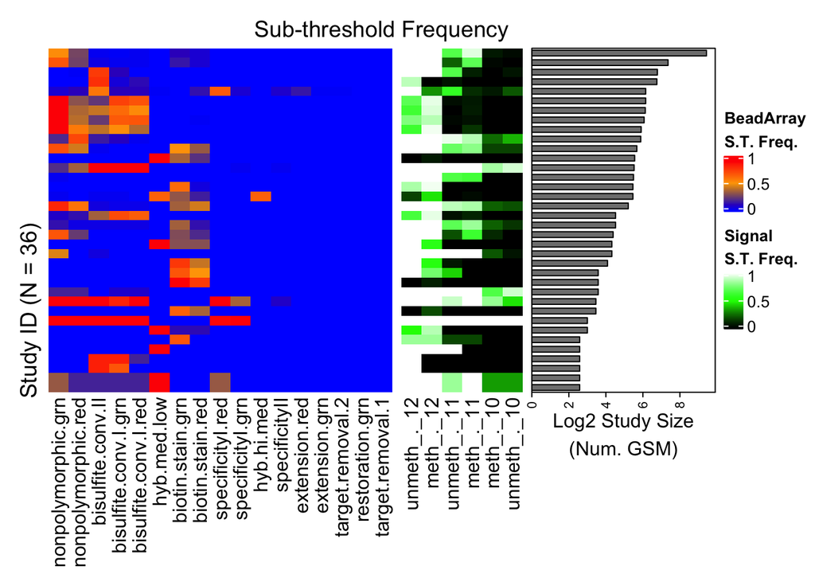

```r
draw(hmlist, row_title = paste0("Study ID (N = ",
                                length(gsesize.subset),")"),
     column_title = "Sub-threshold Frequency",
     heatmap_legend_side = "right", annotation_legend_side = "right")
```

# Figure 3 PCA of autosomal DNAm

Details including sample identification, analyses, and results summaries are detailed in the script `pca_fig3.R`. This script generates the files contained in /Library/Frameworks/R.framework/Versions/4.0/Resources/library/recountmethylationManuscriptSupplement/extdata/pcadata, which are used below to generate the main plots.

## 3A

Run the following to generate the scatterplot of the top two components from PCA of all samples. Red points are noncancer blood, purple points are leukemia samples.

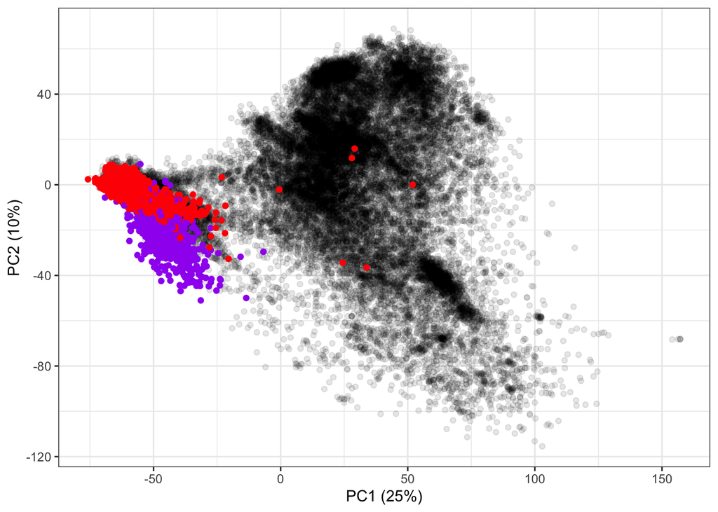

```r
script.name <- "fig3a.R"
source(file.path(scripts.dir, script.name))
fig3a
```

## 3B

Run the following to generate the scatterplot of the top two components from PCA of all samples except blood or leukemias. Blue points are noncancer brain, dark cyan points are brain tumors.

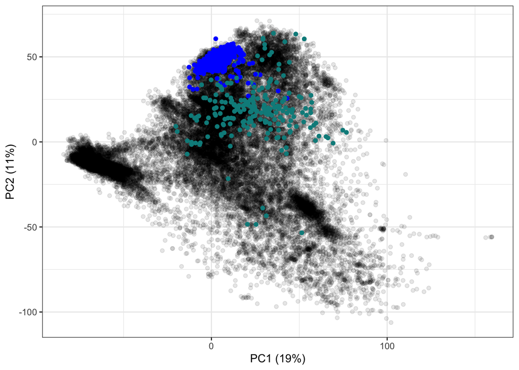

```r
script.name <- "fig3b.R"
source(file.path(scripts.dir, script.name))
fig3b
```

## 3C

Run the following to generate the scatterplot of the top two components from PCA of 7 noncancer tissues: sperm (blue); adipose (dark red); blood (red); brain (purple); buccal (orange); nasal (light green); and liver (dark green).

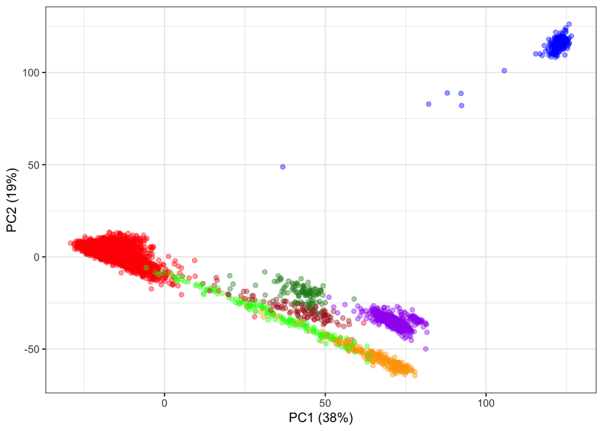

```r
script.name <- "fig3c.R"
source(file.path(scripts.dir, script.name))
fig3c
```

## 3D

Run the following to generate the scatterplot of the top two components from PCA of 6 noncancer tissues: adipose (dark red); blood (red); brain (purple); buccal (orange); nasal (light green); and liver (dark green).

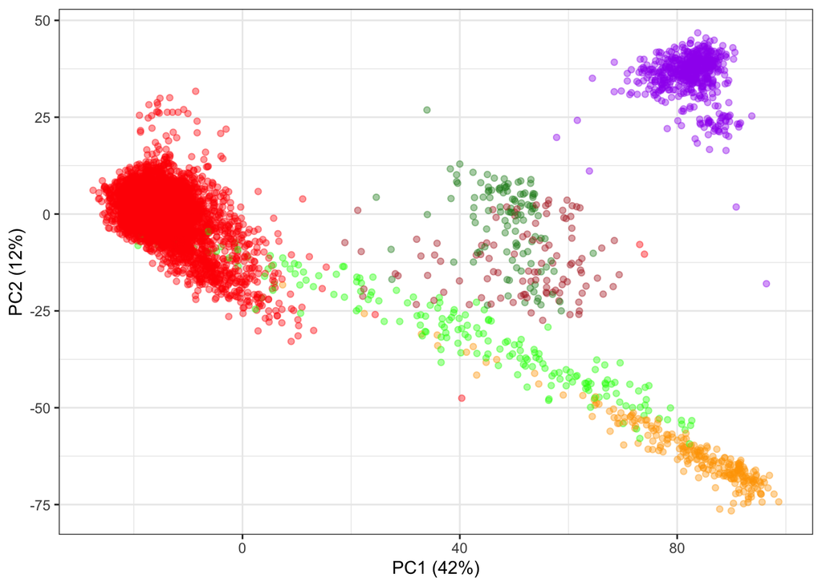

```r
script.name <- "fig3d.R"
source(file.path(scripts.dir, script.name))
fig3d
```

# Figure 4 DNAm variability in noncancer tissues

For analysis details, see also the data analyses vignette in [`recountmethylation`](https://bioconductor.org/packages/devel/bioc/vignettes/recountmethylation/inst/doc/recountmethylation_data_analyses.pdf)

## 4A

Violin plots of 14,000 high variance probes

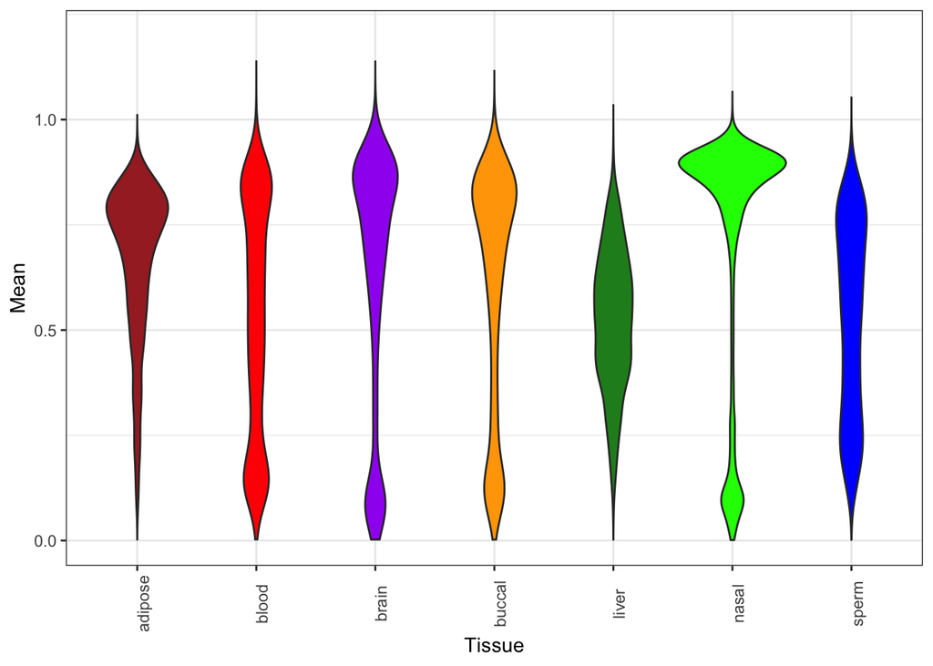

```r
script.name <- "fig4ab.R"
source(file.path(scripts.dir, script.name))
fig4a
```

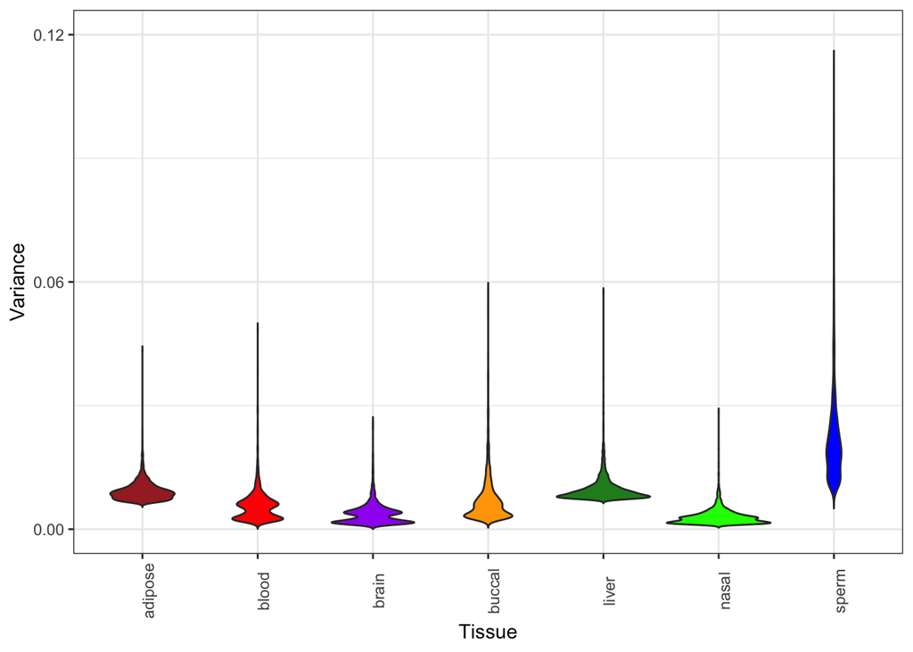

```r
fig4b
```

This section shows how to generate the composite image of stacked barplots showing probe genome region mappings among the 14,000 probes with high tissue-specific variances in 7 noncancer tissues.

```
## locfit 1.5-9.4    2020-03-24
```

```
## Setting options('download.file.method.GEOquery'='auto')
```

```
## Setting options('GEOquery.inmemory.gpl'=FALSE)
```

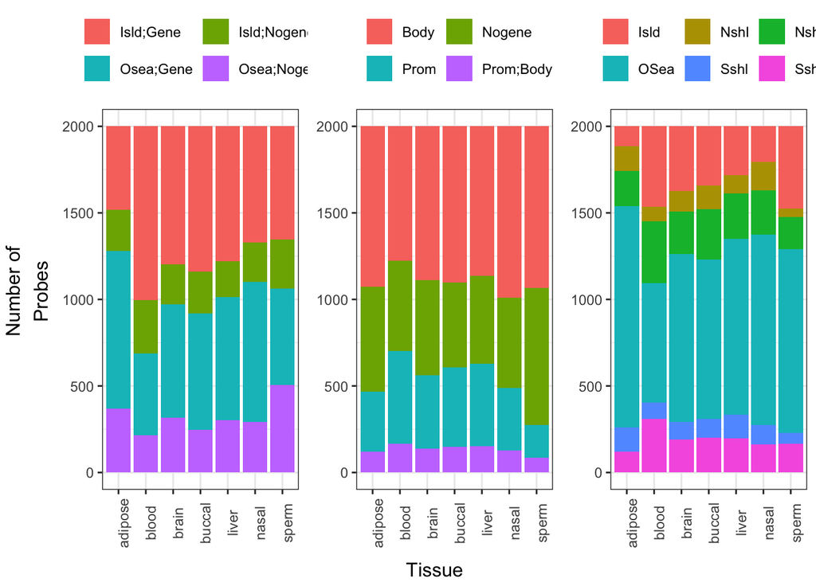

```r
script.name <- "fig4c.R"
source(file.path(scripts.dir, script.name))
```